# Plotting mealworm mass

Mike Crossley

12/6/2021

If you don’t already have R, you will need to install R and then R Studio (see how-to tutorial here: https://www.datacamp.com/community/tutorials/installing-R-windows-mac-ubuntu). Then copy and paste the chunks of code given below into a new R file to follow along with the analysis pipeline.

### Import data

The first thing you need to do is download the data from the google spreadsheet (https://docs.google.com/spreadsheets/d/1ebwxTTXqGgh05ouvSjtzhma46DPML1hyf994NS6zjxU/edit?usp=sharing) as a .csv file:

[figure not shown]

We will then use `read.csv()` to read in our data, stored in a comma-separated value (.csv) file called “New Larvae Growth - raw data.csv”. Note that I have placed the data in a directory called `C:/Users/mcros/Desktop/BuffaloWorm/data/`. You will need to modify this path to reflect where you have stored that data on your computer so that R knows where to grab the data from.

```r
dat = read.csv('C:/Users/mcros/Desktop/BuffaloWorm/data/New Larvae Growth - raw data.csv',header=T)
```

It is good practice to peak at data once you have imported it. There are two ways we can do that. One uses `str()`, short for “structure”, which gives us a summary of the number of variables (columns) and observations (rows) in our data frame. It also tells us what each element is. “chr” = character (or string of text); “int” = integer; “num” = numeric (non-integer numbers).

```r
str(dat)
```

```
## 'data.frame':    40 obs. of  8 variables:
##  $ Dish_ID    : int  1 2 3 4 5 1 2 3 4 5 ...
##  $ Date       : chr  "11/12/21" "11/12/21" "11/12/21" "11/12/21" ...
##  $ Dish_mass_g: num  14.4 14.4 14.4 14.4 14.4 ...
##  $ larvae_g   : num  0.071 0.062 0.0638 0.0595 0.0654 0.0555 0.0541 0.0527 0.0545 0.0652 ...
##  $ Food_mass_g: num  2.04 2.03 2 2.04 2.03 ...
##  $ Colony     : chr  "Bill Dagsboro" "Bill Dagsboro" "Bill Dagsboro" "Bill Dagsboro" ...
##  $ Apple_g    : num  1.15 1.18 1.42 1 1.48 ...
##  $ N_larvae   : int  100 100 100 100 100 100 100 100 100 100 ...
```

Another way to quickly view the data is with `head()`, which shows the first few lines of the data frame

```r
head(dat)
```

```
##   Dish_ID     Date Dish_mass_g larvae_g Food_mass_g        Colony Apple_g
## 1       1 11/12/21     14.4176   0.0710      2.0369 Bill Dagsboro  1.1453
## 2       2 11/12/21     14.4203   0.0620      2.0256 Bill Dagsboro  1.1797
## 3       3 11/12/21     14.4246   0.0638      2.0036 Bill Dagsboro  1.4215
## 4       4 11/12/21     14.4277   0.0595      2.0359 Bill Dagsboro  1.0006
## 5       5 11/12/21     14.4284   0.0654      2.0293 Bill Dagsboro  1.4756
## 6       1 11/12/21     14.4262   0.0555      2.0394         Daisy  0.7423
##   N_larvae
## 1      100
## 2      100
## 3      100
## 4      100
## 5      100
## 6      100
```

### Plot some variables

Okay, now we need to set up our data for plotting. Let’s first plot the change in mass of various components of the experiment over time. To set up our x-axis (time), we need to make sure the R knows that the `Date` column is populated with actual dates (not just character strings).

```r
dat$Date2 = as.Date(dat$Date,format='%m/%d/%Y')
str(dat) #something is wrong with Date2
```

```
## 'data.frame':    40 obs. of  9 variables:
##  $ Dish_ID    : int  1 2 3 4 5 1 2 3 4 5 ...
##  $ Date       : chr  "11/12/21" "11/12/21" "11/12/21" "11/12/21" ...
##  $ Dish_mass_g: num  14.4 14.4 14.4 14.4 14.4 ...
##  $ larvae_g   : num  0.071 0.062 0.0638 0.0595 0.0654 0.0555 0.0541 0.0527 0.0545 0.0652 ...
##  $ Food_mass_g: num  2.04 2.03 2 2.04 2.03 ...
##  $ Colony     : chr  "Bill Dagsboro" "Bill Dagsboro" "Bill Dagsboro" "Bill Dagsboro" ...
##  $ Apple_g    : num  1.15 1.18 1.42 1 1.48 ...
##  $ N_larvae   : int  100 100 100 100 100 100 100 100 100 100 ...
##  $ Date2      : Date, format: "0021-11-12" "0021-11-12" ...
```

Uh-oh. It looks like R didn’t like that our year was just two digits (“21”), so let’s fix that and try converting to date format again.

```r
dat$Date = apply(array(dat$Date),1,function(x){
  y=strsplit(x,'/')[[1]];
  year = paste('20',y[3],sep='');
  return(paste(y[1],y[2],year,sep='/'))
})
dat$Date2 = as.Date(dat$Date,format='%m/%d/%Y')
str(dat) #that worked!
```

```
## 'data.frame':    40 obs. of  9 variables:
##  $ Dish_ID    : int  1 2 3 4 5 1 2 3 4 5 ...
##  $ Date       : chr  "11/12/2021" "11/12/2021" "11/12/2021" "11/12/2021" ...
##  $ Dish_mass_g: num  14.4 14.4 14.4 14.4 14.4 ...
##  $ larvae_g   : num  0.071 0.062 0.0638 0.0595 0.0654 0.0555 0.0541 0.0527 0.0545 0.0652 ...
##  $ Food_mass_g: num  2.04 2.03 2 2.04 2.03 ...
##  $ Colony     : chr  "Bill Dagsboro" "Bill Dagsboro" "Bill Dagsboro" "Bill Dagsboro" ...
##  $ Apple_g    : num  1.15 1.18 1.42 1 1.48 ...
##  $ N_larvae   : int  100 100 100 100 100 100 100 100 100 100 ...
##  $ Date2      : Date, format: "2021-11-12" "2021-11-12" ...
```

Next let’s start by plotting each petri dish’s mass over time.

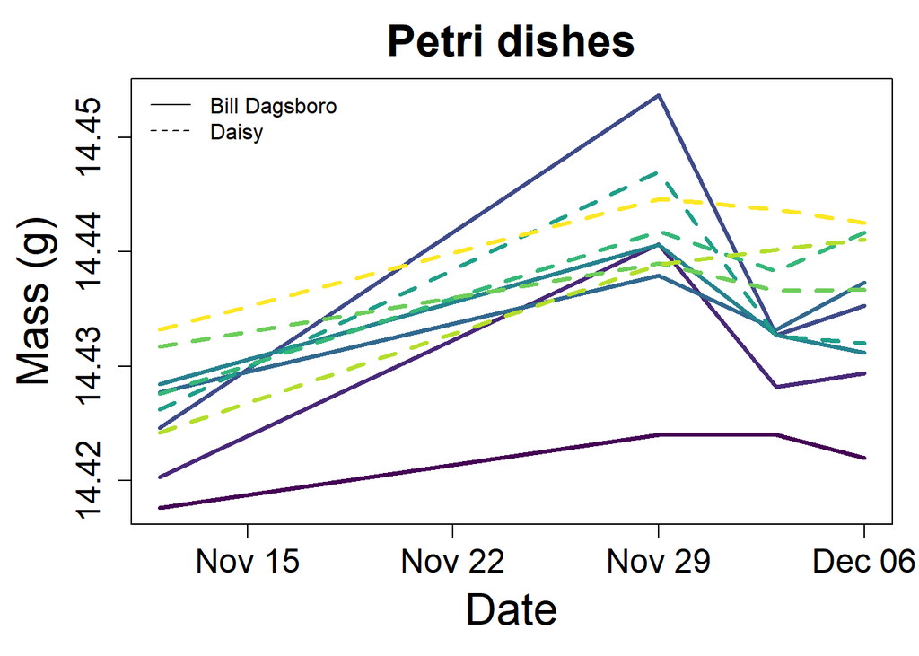

```r
# First, we'll make a unique identifier for each dish by combining the colony name with the dish ID
dat$id = paste(dat$Colony,dat$Dish_ID,sep='_')
ids = unique(dat$id) #vector of unique dishes

#Let's set the color scheme for the lines in our plots. We will draw from an R package called `viridis`.
require('viridis')
pal = viridis(length(ids)) #we draw a color for each unique dish from the viridis color palette

# We will also specify a unique line type for each colony
colonies = unique(dat$Colony)
ltys = c(1,2) #solid line for Bill Dagsboro, dashed line for Daisy

# Then we'll start a new plot using the maximum and minimum dish mass to define our y-axis limits
# We'll also define a vector of dates to serve as our x-axis.
# We set col to 'white' because we are just creating an empty plot to start with.
dates = sort(unique(dat$Date2))

# Plot setup
par(oma=c(0,0,0,0),mar=c(5,5,3,1),cex.main=2,cex.lab=2,cex.axis=1.5) #specify plot margins. Order is bottom,left,top,right. Also specify text font sizes.

# Draw empty plot
plot(x=c(min(dates),max(dates)),y=c(min(dat$Dish_mass_g),max(dat$Dish_mass_g)),col='white',xlab='Date',ylab='Mass (g)',main='Petri dishes')
legend('topleft',legend=colonies,lty=ltys,bty='n') #define plot legend distinguishing colony line types

# Next, we add a line for each petri dish. We will use a `for()` loop to iterate through each dish, specifying the mass over time and a unique color to distinguish dishes and line style to distinguish colonies.
for (i in 1:length(ids)){ #for i in 1 through the number of petri dish IDs, do:
  pos = which(dat$id==ids[i]) #row position for the petri dish with id = ids[i]
  dat2 = dat[pos,] #subset dat to only contain records for ids[i]
  dat2 = dat2[order(dat2$Date2,decreasing=F),] #ensure that dates are in increasing order
  lty1 = ltys[match(unique(dat2$Colony),colonies)] #get line style correpsonding to colony of the ids[i] dish
  lines(x=dat2$Date2,y=dat2$Dish_mass_g,col=pal[i],lty=lty1,lwd=3) #draw a line
}
```

We can do the same for larval mass over time.

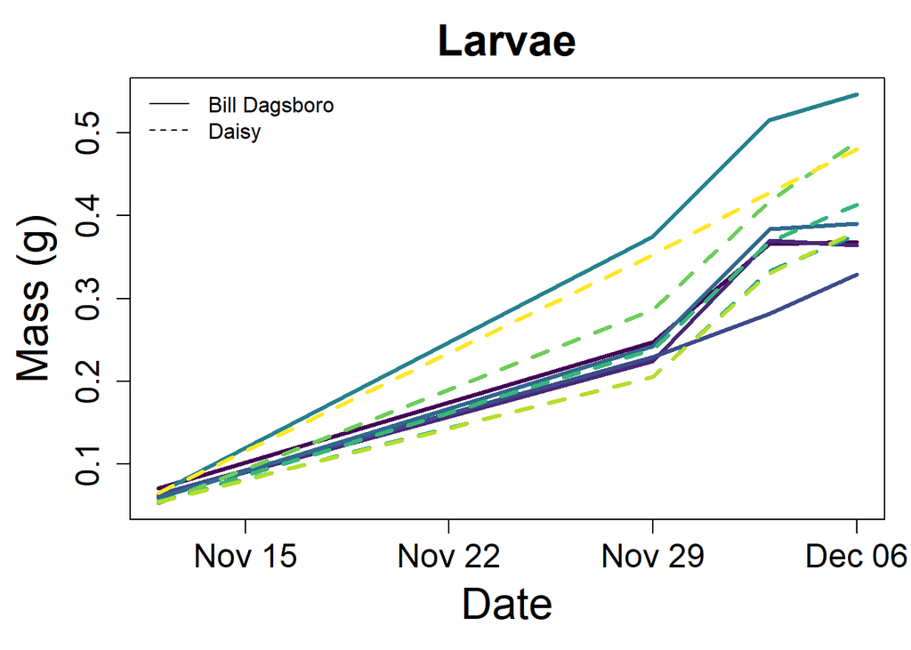

```r
# Plot setup
par(oma=c(0,0,0,0),mar=c(5,5,3,1),cex.main=2,cex.lab=2,cex.axis=1.5) #specify plot margins. Order is bottom,left,top,right. Also specify text font sizes.

# Draw empty plot
plot(x=c(min(dates),max(dates)),y=c(min(dat$larvae_g),max(dat$larvae_g)),col='white',xlab='Date',ylab='Mass (g)',main='Larvae')
legend('topleft',legend=colonies,lty=ltys,bty='n') #define plot legend distinguishing colony line types

# Next, we add a line for each petri dish. We will use a `for()` loop to iterate through each dish, specifying the mass over time and a unique color to distinguish dishes and line style to distinguish colonies.
for (i in 1:length(ids)){ #for i in 1 through the number of petri dish IDs, do:
  pos = which(dat$id==ids[i]) #row position for the petri dish with id = ids[i]
  dat2 = dat[pos,] #subset dat to only contain records for ids[i]
  dat2 = dat2[order(dat2$Date2,decreasing=F),] #ensure that dates are in increasing order
  lty1 = ltys[match(unique(dat2$Colony),colonies)] #get line style correpsonding to colony of the ids[i] dish
  lines(x=dat2$Date2,y=dat2$larvae_g,col=pal[i],lty=lty1,lwd=3) #draw a line
}
```

Next is food mass over time. We’ll move the plot legend to the “topright” so we don’t overlap the lines.

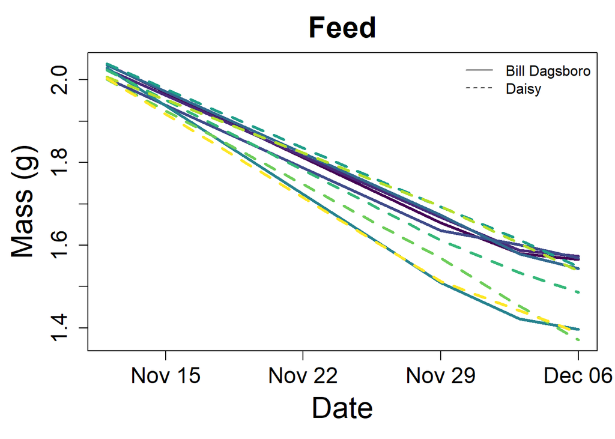

```r
# Plot setup
par(oma=c(0,0,0,0),mar=c(5,5,3,1),cex.main=2,cex.lab=2,cex.axis=1.5) #specify plot margins. Order is bottom,left,top,right. Also specify text font sizes.

# Draw empty plot
plot(x=c(min(dates),max(dates)),y=c(min(dat$Food_mass_g),max(dat$Food_mass_g)),col='white',xlab='Date',ylab='Mass (g)',main='Feed')
legend('topright',legend=colonies,lty=ltys,bty='n') #define plot legend distinguishing colony line types

# Next, we add a line for each petri dish. We will use a `for()` loop to iterate through each dish, specifying the mass over time and a unique color to distinguish dishes and line style to distinguish colonies.
for (i in 1:length(ids)){ #for i in 1 through the number of petri dish IDs, do:
  pos = which(dat$id==ids[i]) #row position for the petri dish with id = ids[i]
  dat2 = dat[pos,] #subset dat to only contain records for ids[i]
  dat2 = dat2[order(dat2$Date2,decreasing=F),] #ensure that dates are in increasing order
  lty1 = ltys[match(unique(dat2$Colony),colonies)] #get line style correpsonding to colony of the ids[i] dish
  lines(x=dat2$Date2,y=dat2$Food_mass_g,col=pal[i],lty=lty1,lwd=3) #draw a line
}
```

Next is apple mass over time.

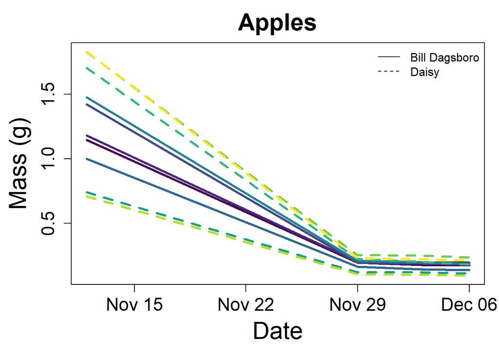

```r
# Plot setup
par(oma=c(0,0,0,0),mar=c(5,5,3,1),cex.main=2,cex.lab=2,cex.axis=1.5) #specify plot margins. Order is bottom,left,top,right. Also specify text font sizes.

# Draw empty plot
plot(x=c(min(dates),max(dates)),y=c(min(dat$Apple_g),max(dat$Apple_g)),col='white',xlab='Date',ylab='Mass (g)',main='Apples')
legend('topright',legend=colonies,lty=ltys,bty='n') #define plot legend distinguishing colony line types

# Next, we add a line for each petri dish. We will use a `for()` loop to iterate through each dish, specifying the mass over time and a unique color to distinguish dishes and line style to distinguish colonies.
for (i in 1:length(ids)){ #for i in 1 through the number of petri dish IDs, do:
  pos = which(dat$id==ids[i]) #row position for the petri dish with id = ids[i]
  dat2 = dat[pos,] #subset dat to only contain records for ids[i]
  dat2 = dat2[order(dat2$Date2,decreasing=F),] #ensure that dates are in increasing order
  lty1 = ltys[match(unique(dat2$Colony),colonies)] #get line style correpsonding to colony of the ids[i] dish
  lines(x=dat2$Date2,y=dat2$Apple_g,col=pal[i],lty=lty1,lwd=3) #draw a line
}
```

Finally, we can look at larva survival over time.

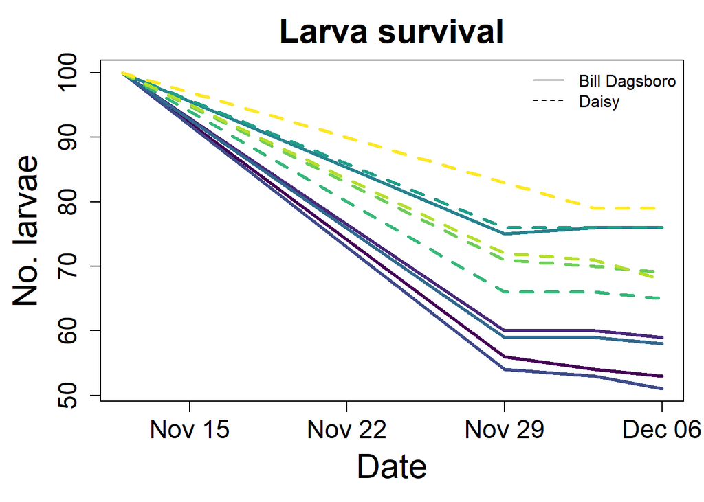

```r
# Plot setup
par(oma=c(0,0,0,0),mar=c(5,5,3,1),cex.main=2,cex.lab=2,cex.axis=1.5) #specify plot margins. Order is bottom,left,top,right. Also specify text font sizes.

# Draw empty plot
plot(x=c(min(dates),max(dates)),y=c(min(dat$N_larvae),max(dat$N_larvae)),col='white',xlab='Date',ylab='No. larvae',main='Larva survival')
legend('topright',legend=colonies,lty=ltys,bty='n') #define plot legend distinguishing colony line types

# Next, we add a line for each petri dish. We will use a `for()` loop to iterate through each dish, specifying the mass over time and a unique color to distinguish dishes and line style to distinguish colonies.
for (i in 1:length(ids)){ #for i in 1 through the number of petri dish IDs, do:
  pos = which(dat$id==ids[i]) #row position for the petri dish with id = ids[i]
  dat2 = dat[pos,] #subset dat to only contain records for ids[i]
  dat2 = dat2[order(dat2$Date2,decreasing=F),] #ensure that dates are in increasing order
  lty1 = ltys[match(unique(dat2$Colony),colonies)] #get line style correpsonding to colony of the ids[i] dish
  lines(x=dat2$Date2,y=dat2$N_larvae,col=pal[i],lty=lty1,lwd=3) #draw a line
}
```

You know, we might want to see how average larval mass changed over time, accounting for the decrease in survival over time.

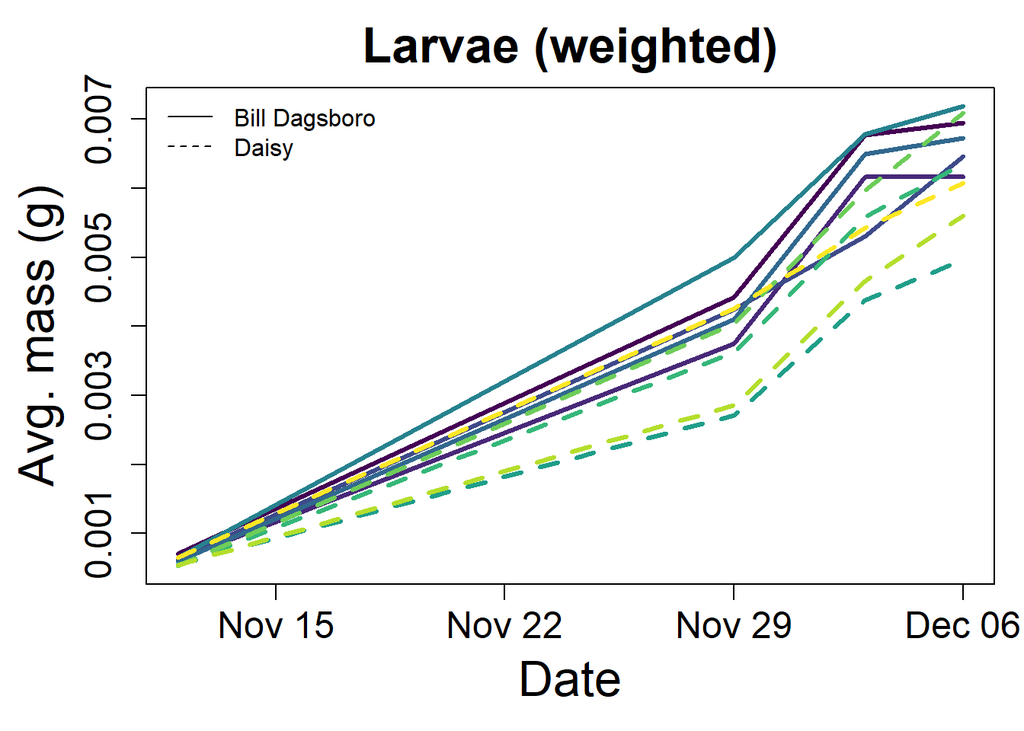

```r
# Add a new column that divides larval mass by number of larvae
dat$Avg.larva.mass = dat$larvae_g / dat$N_larvae

# Plot setup
par(oma=c(0,0,0,0),mar=c(5,5,3,1),cex.main=2,cex.lab=2,cex.axis=1.5) #specify plot margins. Order is bottom,left,top,right. Also specify text font sizes.

# Draw empty plot
plot(x=c(min(dates),max(dates)),y=c(min(dat$Avg.larva.mass),max(dat$Avg.larva.mass)),col='white',xlab='Date',ylab='Avg. mass (g)',main='Larvae (weighted)')
legend('topleft',legend=colonies,lty=ltys,bty='n') #define plot legend distinguishing colony line types

# Next, we add a line for each petri dish. We will use a `for()` loop to iterate through each dish, specifying the mass over time and a unique color to distinguish dishes and line style to distinguish colonies.
for (i in 1:length(ids)){ #for i in 1 through the number of petri dish IDs, do:
  pos = which(dat$id==ids[i]) #row position for the petri dish with id = ids[i]
  dat2 = dat[pos,] #subset dat to only contain records for ids[i]
  dat2 = dat2[order(dat2$Date2,decreasing=F),] #ensure that dates are in increasing order
  lty1 = ltys[match(unique(dat2$Colony),colonies)] #get line style correpsonding to colony of the ids[i] dish
  lines(x=dat2$Date2,y=dat2$Avg.larva.mass,col=pal[i],lty=lty1,lwd=3) #draw a line
}
```

Question: How does this plot differ from the one above that reported larval mass over time?

### Plotting everything at once

Okay, so we might be interested in plotting everything together so we can get one synoptic look at the results from the experiment. For that we will define a plotting function, and apply it to each variable of interest.

```r
plot.exp = function(d,v){
  d$id = paste(d$Colony,d$Dish_ID,sep='_')
  ids = unique(d$id)
  pal = viridis(length(ids))
  colonies = unique(d$Colony)
  ltys = c(1,2) #this will need to be modified if more than one colony is represented
  dates = sort(unique(d$Date2))
  vpos = which(colnames(d)==v)
  plot(x=c(min(dates),max(dates)),y=c(min(d[,vpos]),max(d[,vpos])),col='white',xlab='Date',ylab='Mass (g)',main=v)
  legend('topleft',legend=colonies,lty=ltys,bty='n')
  for (i in 1:length(ids)){
    pos = which(d$id==ids[i])
    d2 = dat[pos,]
    d2 = d2[order(d2$Date2,decreasing=F),]
    lty1 = ltys[match(unique(d2$Colony),colonies)]
    lines(x=d2$Date2,y=d2[,vpos],col=pal[i],lty=lty1,lwd=3) #draw a line
  }
}
```

Now that we defined our function, we can apply it to the variables of interest and make the plots

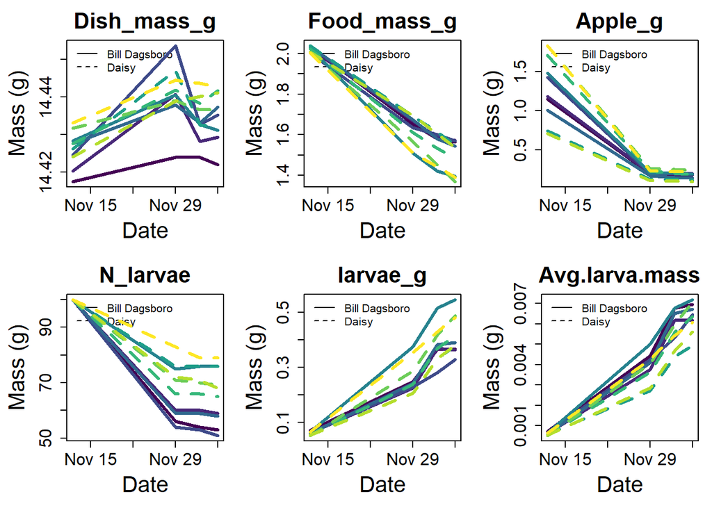

```r
# Plot setup. Note mfrow=c(2,3). This means the plot layout includes 2 rows and 3 columns.
require('viridis')
par(mfrow=c(2,3),oma=c(0,0,0,0),mar=c(5,5,3,1),cex.main=2,cex.lab=2,cex.axis=1.5)
vars = c('Dish_mass_g','Food_mass_g','Apple_g','N_larvae','larvae_g','Avg.larva.mass')
for (i in 1:length(vars)){
  plot.exp(dat,vars[i])
}
```